# Introduction to R

Not so basics

# Part 3

- Visualization
- Vectors
- Packages

# Visualization

It’s impossible to overstate the importance of visualization in data analysis.

- Helps us explore data
- Suggest a model
- Assess the validity of a model and its parameters
- Vital for a non-technical audience

# Visualization in R

4 plotting engines (at least)

- base plotting system
- lattice
- ggplot2
- rCharts

We’ll look at the base plotting system now and ggplot2 after lunch.

# Common geometric objects

- scatter
- line
- hist
- density
- boxplot
- barplot
- dotplot

plot is the most basic graphics command. There are several dozen options that you can set. Spend a lot of time reading the documentation and experimenting.

Open your first script.

# A basic scatter plot

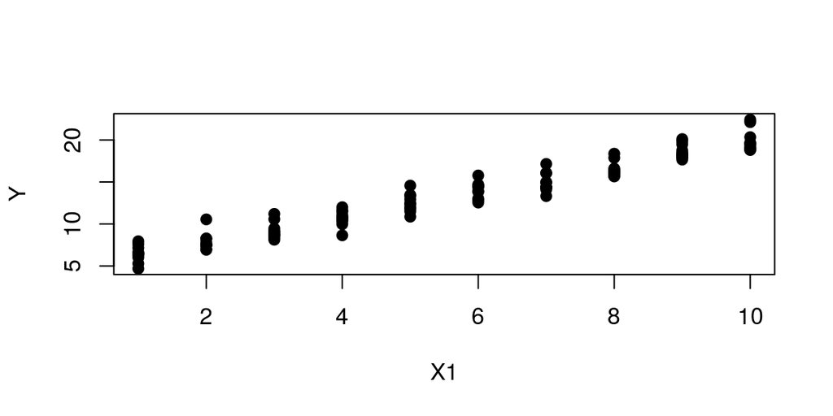

```r
source("../scripts/BasicScript.R")
plot(X1, Y, pch=19)
```

# Add lines

The functions ‘lines’ and ‘points’ will add (wait for it) lines and points to a pre-existing plot.

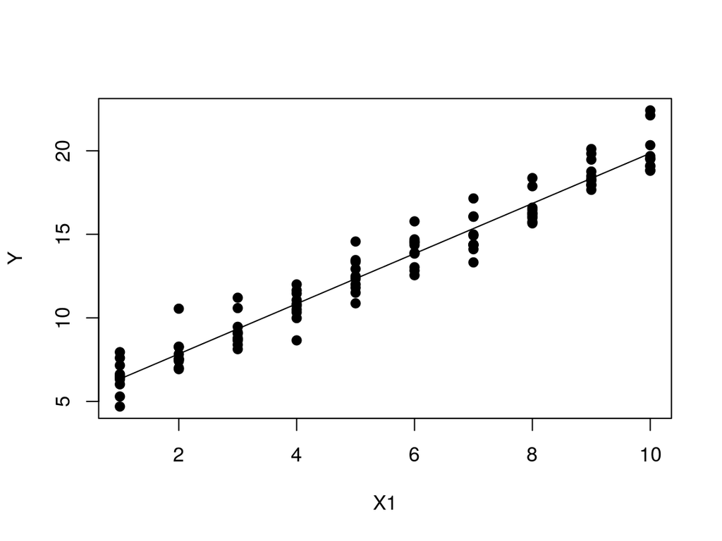

```r
lines(X1, yHat)
```

Can everyone generate a scatter plot?

# Histogram

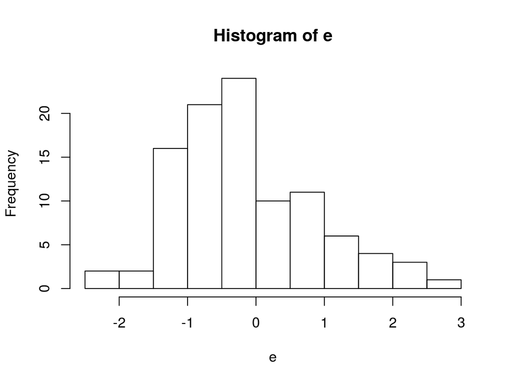

```r
hist(e)
```

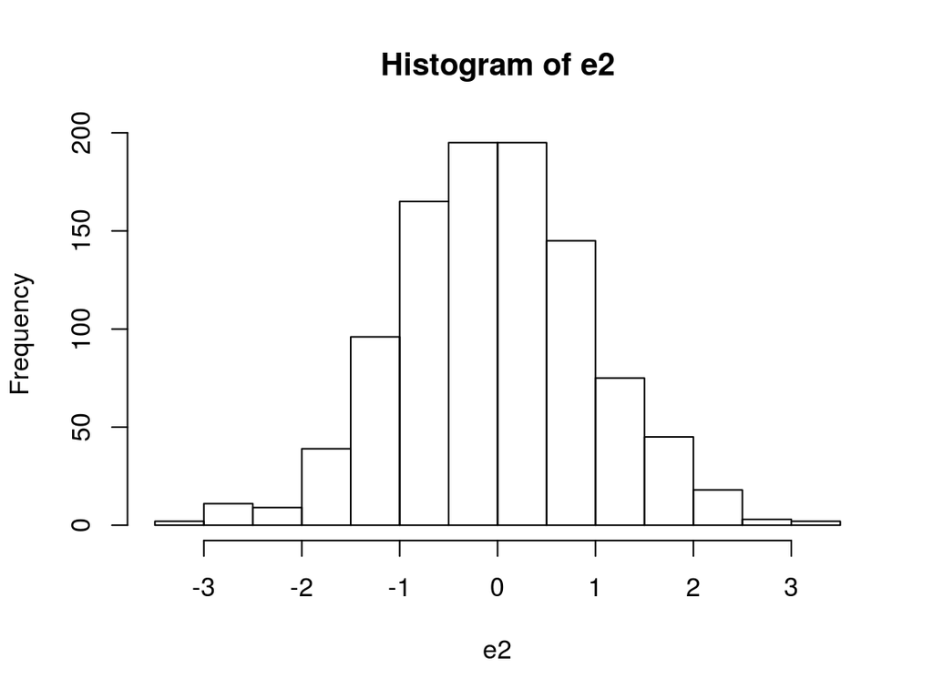

```r
set.seed(1234)
e2 = rnorm(1000, mean=0, sd=1)
hist(e2)
```

# Density plot

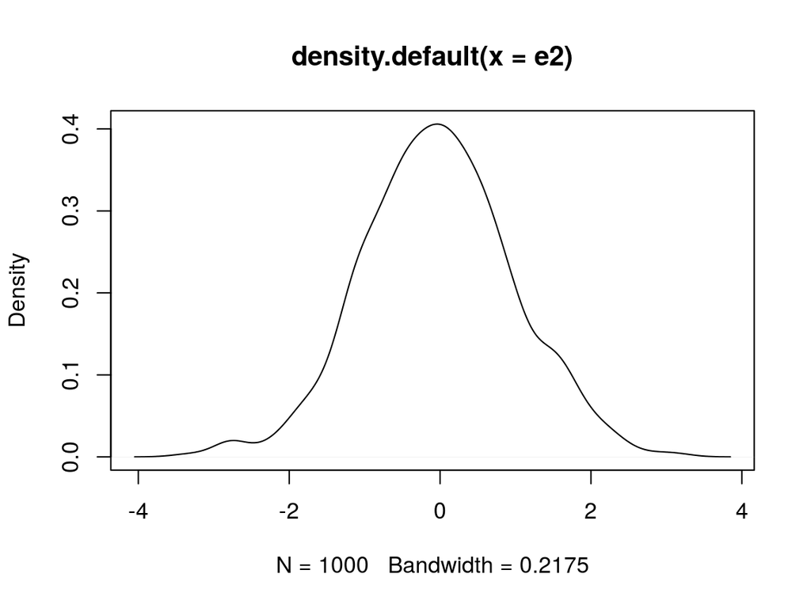

```r
plot(density(e2))
```

# Boxplot

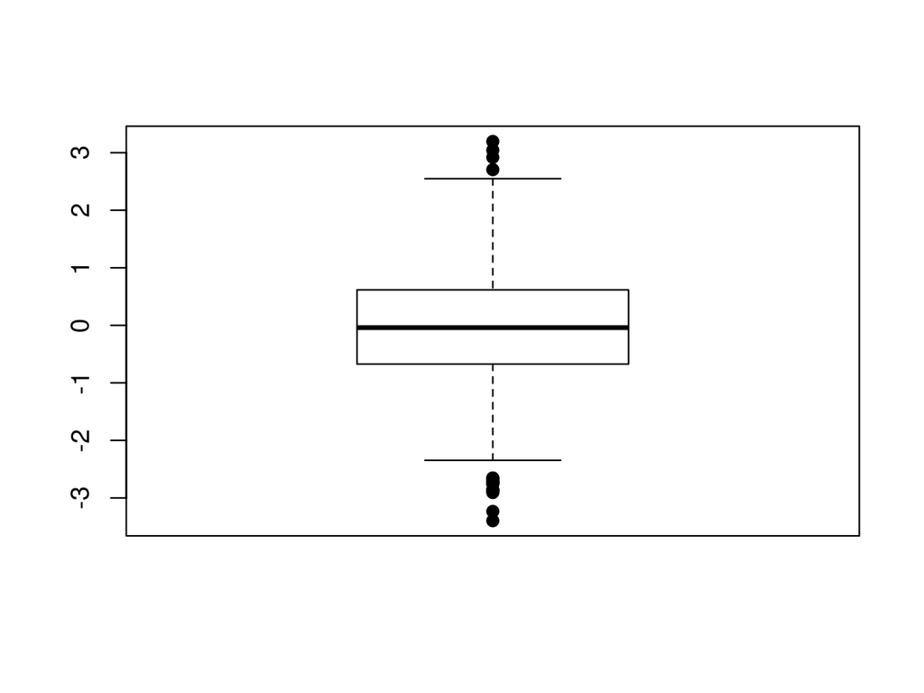

```r
boxplot(e2, pch=19)
```

# Plotting a formula

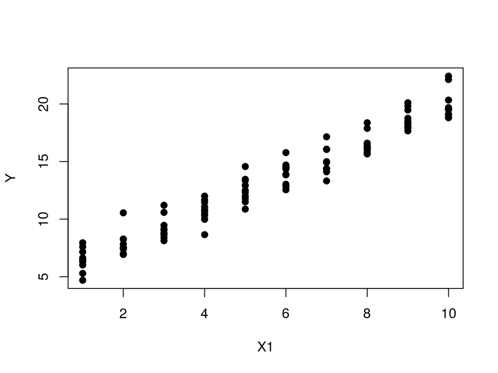

```r
plot(Y ~ X1, pch=19)
```

# Emphasizing outliers

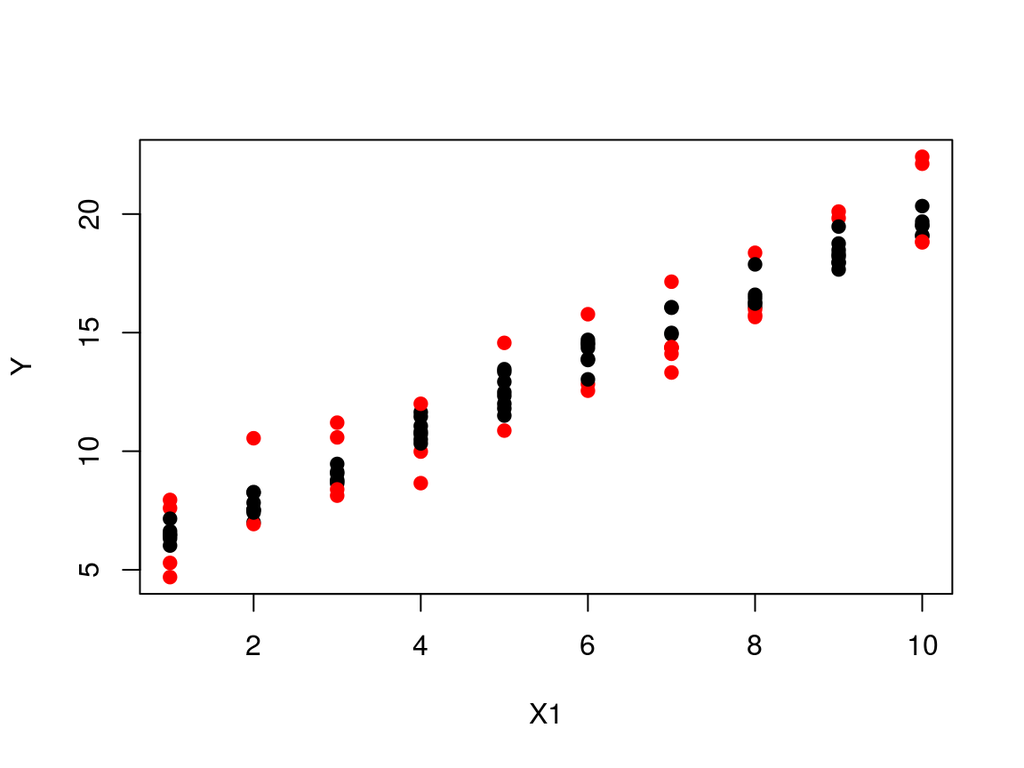

```r
colors = ifelse(abs(e) > 1.0, "red", "black")
plot(Y ~ X1, pch=19, col=colors)
```

# Other ways to emphasize outliers

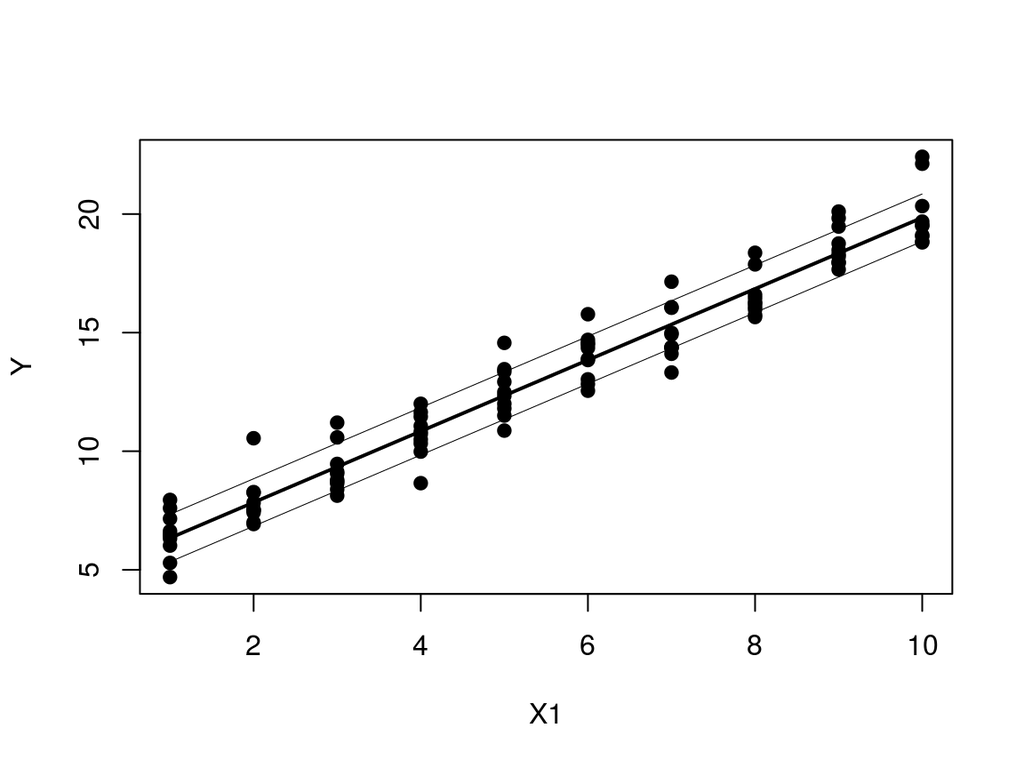

```r
plot(Y ~ X1, pch=19)
lines(X1, yHat, lwd=2)
lines(X1, yHat+1, lty="dotted", lwd=0.5)
lines(X1, yHat-1, lty="dotted", lwd=0.5)
```

# Resources

- [Nathan Yau - FlowingData.com](http://flowingdata.com/)
- [Stephen Few - PerceptualEdge.com](http://www.perceptualedge.com/)
- [Edward Tufte - edwardtufte.com](http://www.edwardtufte.com/tufte/)
- [junkcharts.typepad.com](http://junkcharts.typepad.com/)

# Introducing vectors

In R, every variable is a vector. Think of a set of cells in a spreadsheet. Here, e is a vector with N values. X1 is the sequence of integers from 1 through 10 repeated 10 times. Vectors can grow and shrink automatically. No need to move cells around on a sheet. No need to copy formulas or change named ranges.

```r
e  <- rnorm(N, mean = 0, sd = 1)
X1 <- rep(seq(1,10), 10)
Y  <- B0 + B1 * X1 + e
```

# Vector properties

- Vectors have one dimension
- Higher dimensions are possible via matrices and arrays
- Every element in a vector must be the same type
- Different types are possible by using a list or a data frame
- Possible to add metadata via attributes

# Vector construction

Vectors are constructed in one of several ways:

- Construction from a sequence
- Concatenation
- Return from a function or operation
- Growth by assignment

# Vector sequence

```r
i <- 1:5
year = 2000:2004
pies = seq(from = 0, by = pi, length.out = 5)
```

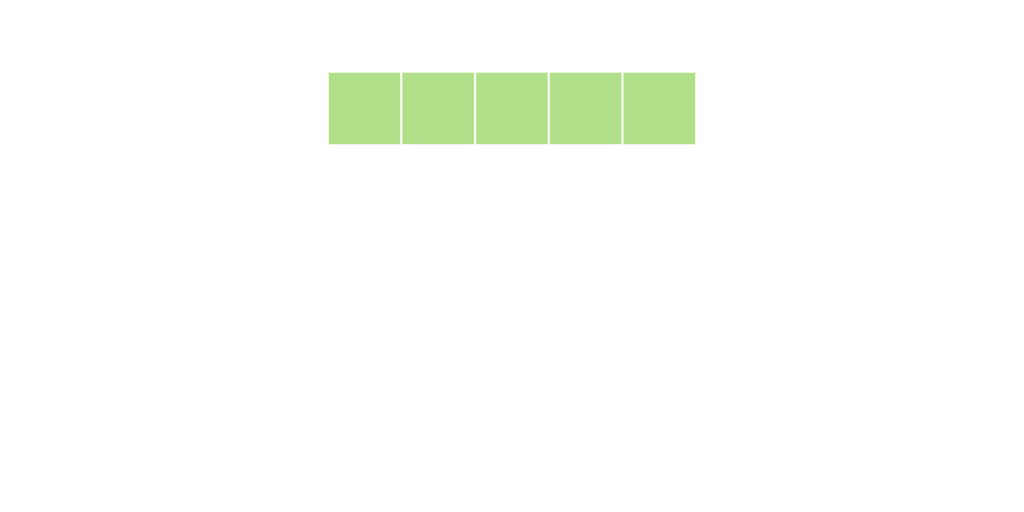

# Concatenation

```r
i <- c(1, 2, 3, 4, 5)
j <- c(6, 7, 8, 9, 10)
k <- c(i, j)
l <- c(1:5, 6:10)
```

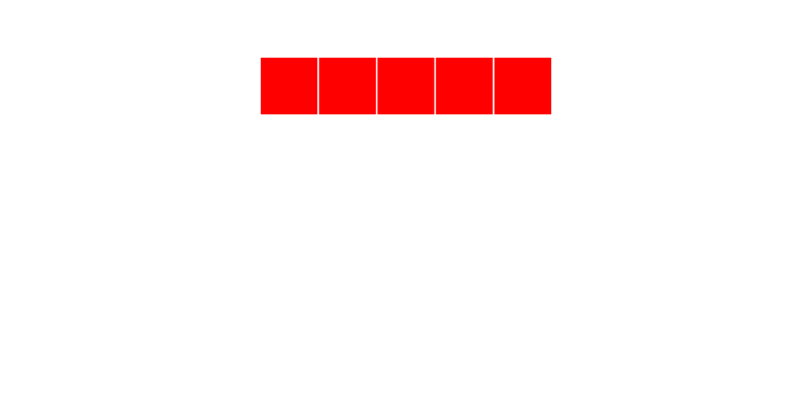

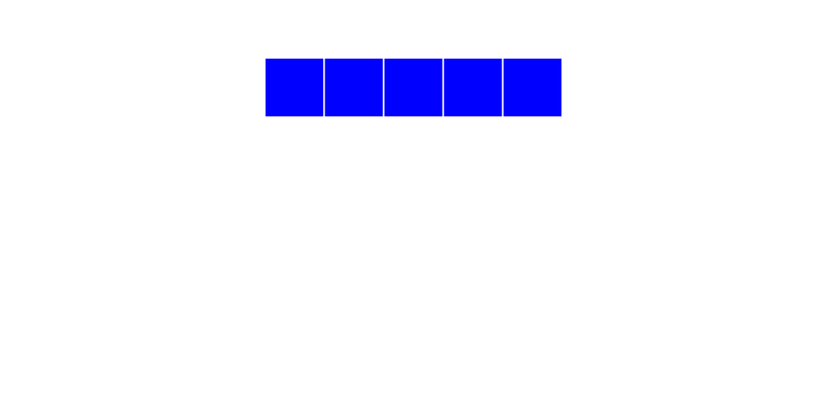

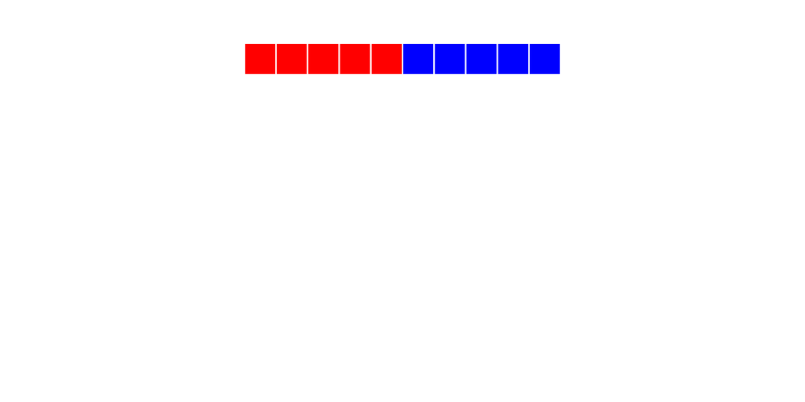

# Return and growth

```r
i = rep(pi, 100)
i = sample(1:10, 4)
i
```

```
## [1]  2 10  5  8
```

```r
i[30] = 3
i
```

```
##  [1]  2 10  5  8 NA NA NA NA NA NA NA NA NA NA NA NA NA NA NA NA NA NA NA
## [24] NA NA NA NA NA NA  3
```

# Vector access - by index

Vectors may be accessed by their numeric indices. Remember, ‘:’ is shorthand to generate a sequence.

```r
e[1]
e[1:4]
e[c(1,3)]
```

# Vector access - logical access

Vectors may be accessed logically.

```r
i = 1:4
i[c(TRUE, FALSE, FALSE, TRUE)]
i[i > 2]
which(i > 2)
i[which(i > 2)]
b = i > 2
i[b]
```

# Summarization - Part I

```r
x = 1:50
sum(x)
mean(x)
max(x)
length(x)
```

# Set theory - Part I

```r
x <- 1:10
y <- 1:5
y %in% x
```

```
## [1] TRUE TRUE TRUE TRUE TRUE
```

# More vector functions

```r
x <- c(5, 3, 2, 4, 1)
order(x)
```

```
## [1] 5 3 2 4 1
```

```r
x[order(x)]
```

```
## [1] 1 2 3 4 5
```

Vectors may be used in arithmetic operations. Y is now a vector with length equal to the longest vector used in the calculation.

```r
Y = B0 + B1 * X1 + e
```

Question: B0 and B1 are vectors of length 1. X1 and e are vectors of length 100. How are they combined?

# Recycling

R will “recycle” vectors until there are enough elements to perform an operation. Everything gets as “long” as the longest vector in the operation. For scalar operations on a vector this doesn’t involve any drama. Try the following code:

```r
vector1 = 1:10
vector2 = 1:5
scalar = 3

print(vector1 + scalar)
```

```
##  [1]  4  5  6  7  8  9 10 11 12 13
```

```r
print(vector2 + scalar)
```

```
## [1] 4 5 6 7 8
```

```r
print(vector1 + vector2)
```

```
##  [1]  2  4  6  8 10  7  9 11 13 15
```

If you understand vectors- how to create them, how to manipulate them, how to access the elements, you’re well on your way to grasping how to handle other objects in R. Fundamentally, *everything* in R is a vector sooner or later.

# Exercise - Vectors

Create a vector of length 10, with years starting from 1980.

Create a vector with values from 1972 to 2012 in increments of four (1972, 1976, 1980, etc.)

Construct the following vectors:

```r
FirstName <- c("Richard", "James", "Ronald", "Ronald"
              , "George", "William", "William", "George"
              , "George", "Barack")
LastName <- c("Nixon", "Carter", "Reagan", "Reagan"
              , "Bush", "Clinton", "Clinton", "Bush"
              , "Bush", "Obama")
ElectionYear <- seq(1972, 2012, 4)
```

List the vectors in order by first name.

List the vectors in order by last name.

Create vector of years when someone named “George” was elected.

# What’s a package?

- Allows any user to extend R’s capabilities
- Must conform to a well-defined standard
- Easy to install and update
- Open source means users may test and improve the code
- Can access C or FORTRAN run-time libraries to improve performance

# Installing packages

Several ways:

- From a CRAN mirror
- Locally
- Copy someone else’s library directory
- From GitHub

The library path may be anywhere! If you have a local document repository this is a great place to store packages without irritating your IT dept.

```r
.libPaths()
list.files(.libPaths()[1])

install.packages("ggplot2")

remove.packages("IdontWantThisAnymore")

# Load an installed package into memory
library(MRMR)

# Will load the package and return TRUE/FALSE
# if the package could be loaded
require(MRMR)
```

Can everyone install a package?